# Generating Molecules with MolGAN

The architecture consits of 3 main sections: a generator, a dicriminator, and a reward network.

The generator takes a sample (z) from a standard normal distribution to generate an a graph using a MLP (this limits the network to a fixed maximum size) to generate the graph at once. Sepcifically a dense adjacency tensor A (bond types) and an annotation matrix X (atom types) are produced. Since these are probabilities, a discrete, sparse x and a are generated through categorical sampling.

The discriminator and reward network have the same architectures and recieve graphs as inputs. A Relational-GCN and MLPs are used to produce the singular output.

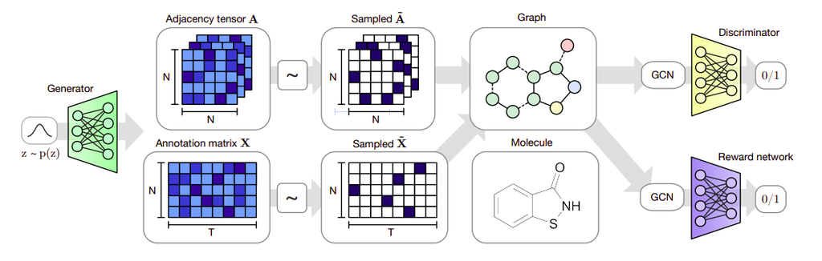

## Setup

To run DeepChem within Colab, you'll need to run the following cell of installation commands.

```python
!pip install --pre deepchem
import deepchem
deepchem.__version__
```

```
'2.6.1'
```

Import the packages you'll need.

```python
import numpy as np
import matplotlib.pyplot as plt
import pandas as pd
import os
from collections import OrderedDict

import deepchem as dc
import deepchem.models
from deepchem.models import BasicMolGANModel as MolGAN
from deepchem.models.optimizers import ExponentialDecay
import tensorflow as tf
from tensorflow import one_hot
from rdkit import Chem
from rdkit.Chem.Draw import IPythonConsole
from rdkit.Chem import Draw

from deepchem.feat.molecule_featurizers.molgan_featurizer import GraphMatrix
```

Download, load, and extract the SMILES strings from the tox21 dataset. The original paper used the QM9 dataset, however we use the tox21 dataset here to save time.

```python
# Download from MolNet
# Try tox21 or LIPO dataset
tasks, datasets, transformers = dc.molnet.load_tox21()
df = pd.DataFrame(data={'smiles': datasets[0].ids})
```

Specify the maximum number of atoms to enocde for the featurizer and the MolGAN network. The higher the number of atoms, the more data you'll have in the dataset. However, this also increases the model complexity as the input dimensions become higher.

```python
num_atoms = 12
```

```python
df
```

|  | smiles |
| --- | --- |
| 0 | CC(O)(P(=O)(O)O)P(=O)(O)O |
| 1 | CC(C)(C)OOC(C)(C)CCC(C)(C)OOC(C)(C)C |
| 2 | OC[C@H](O)[C@@H](O)[C@H](O)CO |
| 3 | CCCCCCCC(=O)[O-].CCCCCCCC(=O)[O-].[Zn+2] |
| 4 | CC(C)COC(=O)C(C)C |
| ... | ... |
| 6259 | CC1CCCCN1CCCOC(=O)c1ccc(OC2CCCCC2)cc1 |
| 6260 | Cc1cc(CCCOc2c(C)cc(-c3noc(C(F)(F)F)n3)cc2C)on1 |
| 6261 | O=C1OC(OC(=O)c2cccnc2Nc2cccc(C(F)(F)F)c2)c2ccc... |
| 6262 | CC(=O)C1(C)CC2=C(CCCC2(C)C)CC1C |
| 6263 | CC(C)CCC[C@@H](C)[C@H]1CC(=O)C2=C3CC[C@H]4C[C@... |

6264 rows × 1 columns

Uncomment the first line if you want to subsample from the full dataset.

```python
#data = df[['smiles']].sample(4000, random_state=42)
data = df
```

Initialize the featurizer with the maxmimum number of atoms per molecule. atom_labels is a parameter to pass the atomic number of atoms you want to be able to parse. Similar to the num_atoms parameter above, more atom_labels means more data, though the model gets more complex/unstable.

```python
# create featurizer
feat = dc.feat.MolGanFeaturizer(max_atom_count=num_atoms, atom_labels=[0, 5, 6, 7, 8, 9, 11, 12, 13, 14]) #15, 16, 17, 19, 20, 24, 29, 35, 53, 80])
```

Extract the smiles from the dataframe as a list of strings

```python
smiles = data['smiles'].values
```

Filter out the molecules with too many atoms to reduce the number of unnecessary error messages in later steps.

```python
filtered_smiles = [x for x in smiles if Chem.MolFromSmiles(x).GetNumAtoms() < num_atoms]
```

```
RDKit WARNING: [01:16:58] WARNING: not removing hydrogen atom without neighbors
```

```python
# featurize molecules
features = feat.featurize(filtered_smiles)
```

[output not shown]

[output cut: 1358 more lines]

[output not shown]

Remove more invalid molecules.

```python
indices = [ i for i, data in enumerate(features) if type(data) is GraphMatrix ]
print(indices)
features = [features[i] for i in indices]
```

```
[1, 2, 3, 4, 5, 6, 7, 8, 9, 10, 13, 15, 16, 18, 19, 20, 21, 22, 23, 24, 26, 28, 29, 30, 31, 34, 35, 36, 37, 38, 43, 46, 47, 48, 50, 51, 52, 53, 56, 58, 59, 60, 62, 63, 64, 65, 69, 70, 72, 73, 74, 76, 77, 78, 79, 80, 83, 84, 85, 86, 88, 89, 92, 93, 94, 95, 96, 97, 99, 100, 101, 102, 103, 104, 105, 10…
```

Instantiate the MolGAN model and set the learning rate and maximum number of atoms as the size of the vertices. Then, we create the dataset in the format of the input to MolGAN.

```python
# create model
gan = MolGAN(learning_rate=ExponentialDecay(0.001, 0.9, 5000), vertices=num_atoms)
dataset = dc.data.NumpyDataset([x.adjacency_matrix for x in features],[x.node_features for x in features])
```

Define the iterbatches function because the gan_fit function requires an iterable for the batches.

```python
def iterbatches(epochs):
    for i in range(epochs):
        for batch in dataset.iterbatches(batch_size=gan.batch_size, pad_batches=True):
            adjacency_tensor = one_hot(batch[0], gan.edges)
            node_tensor = one_hot(batch[1], gan.nodes)
            yield {gan.data_inputs[0]: adjacency_tensor, gan.data_inputs[1]:node_tensor}
```

Train the model with the fit_gan function and generate molecules with the predict_gan_generator function.

```python
gan.fit_gan(iterbatches(25), generator_steps=0.2, checkpoint_interval=5000)
generated_data = gan.predict_gan_generator(1000)
```

```
Ending global_step 349: generator average loss -1.67888, discriminator average loss -13.2226
TIMING: model fitting took 11.961 s
Generating 1000 samples
```

Convert the generated graphs to RDKit molecules.

```python
nmols = feat.defeaturize(generated_data)
print("{} molecules generated".format(len(nmols)))
```

[output not shown]

[output cut: 218 more lines]

[output not shown]

```
1000 molecules generated
```

[output not shown]

Remove invalid molecules from list.

```python
nmols = list(filter(lambda x: x is not None, nmols))
```

Print out the number of valid molecules, but training can be unstable so some the number can vary significantly.

```python
# currently training is unstable so 0 is a common outcome
print ("{} valid molecules".format(len(nmols)))
```

```
687 valid molecules
```

Remove duplicate generated molecules.

```python
nmols_smiles = [Chem.MolToSmiles(m) for m in nmols]
nmols_smiles_unique = list(OrderedDict.fromkeys(nmols_smiles))
nmols_viz = [Chem.MolFromSmiles(x) for x in nmols_smiles_unique]
print ("{} unique valid molecules".format(len(nmols_viz)))
```

```
29 unique valid molecules
```

Print out up to 100 unique valid molecules.

```python
img = Draw.MolsToGridImage(nmols_viz[0:100], molsPerRow=5, subImgSize=(250, 250), maxMols=100, legends=None, returnPNG=False)
```

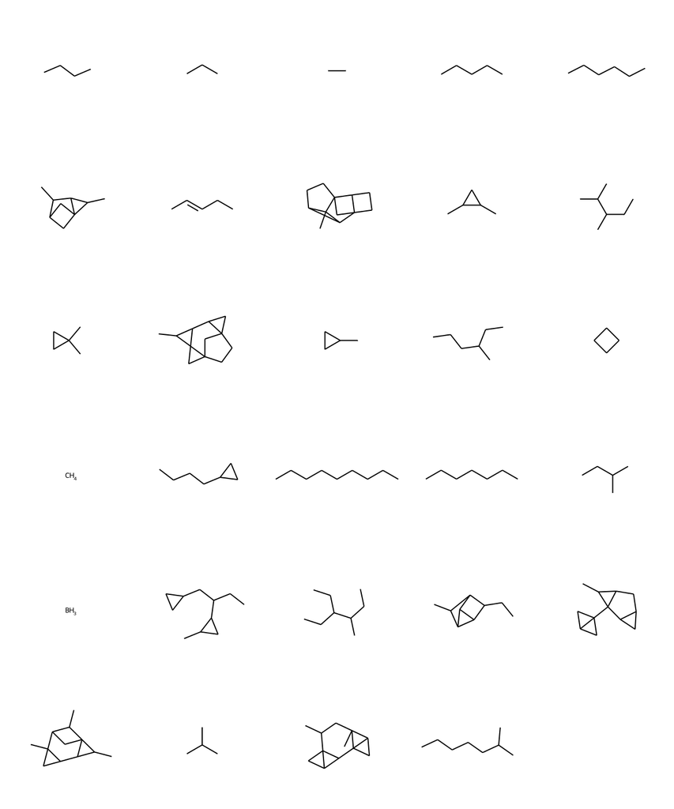

```python
img
```

This is an example of what the molecules should look like.

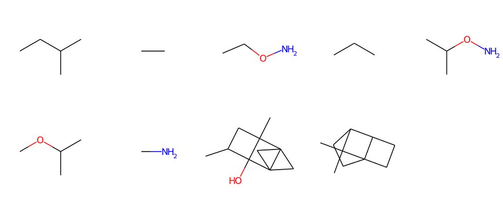